# Duncan Dataset Analysis

Lohit Marla

2023-10-28

The dataset “Duncan” comprises information pertaining to multiple professions, including “bc,” “wc,” and “prof,” along with associated quantitative attributes such as income, education, and prestige. An examination of the data structure for Duncan reveals that the variable “type” is categorical with three distinct levels, while the remaining variables are represented as integer values.

```r
library(ggplot2)
library("car")
data("Duncan")
str(Duncan)
```

```
## 'data.frame':    45 obs. of  4 variables:
##  $ type     : Factor w/ 3 levels "bc","prof","wc": 2 2 2 2 2 2 2 2 3 2 ...
##  $ income   : int  62 72 75 55 64 21 64 80 67 72 ...
##  $ education: int  86 76 92 90 86 84 93 100 87 86 ...
##  $ prestige : int  82 83 90 76 90 87 93 90 52 88 ...
```

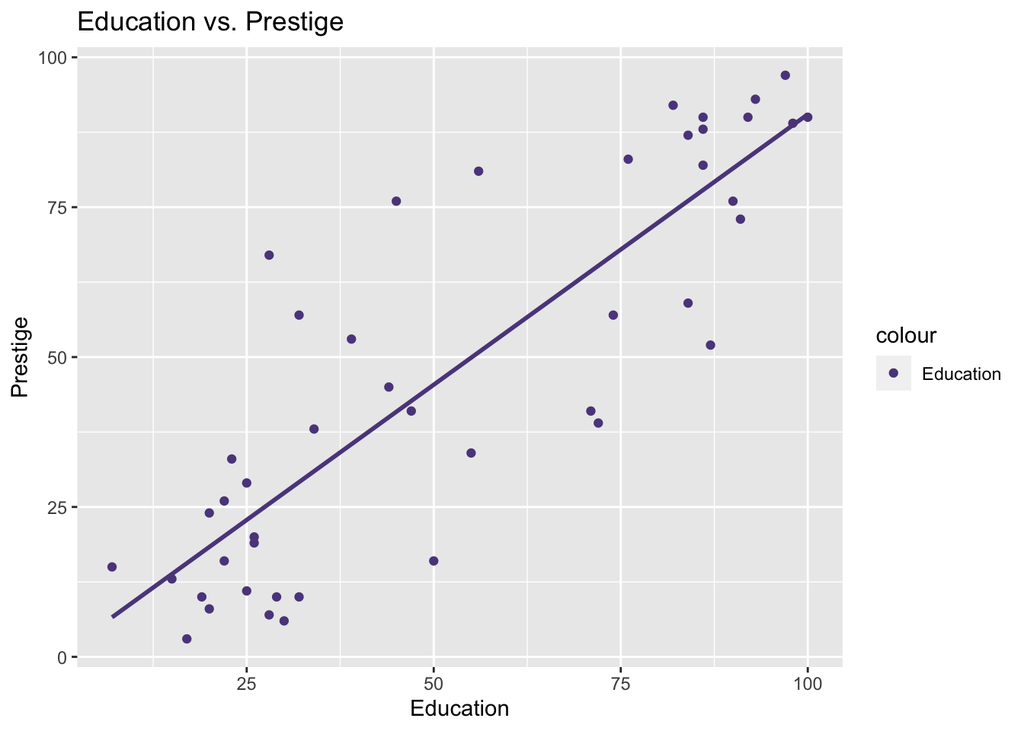

```r
education_color <- "mediumpurple4"
income_color <- "darkgreen"

par(bg = "black")
ggplot(data = Duncan, aes(x = education, y = prestige, color = "Education")) +
  geom_point() +
  geom_smooth(method = "lm", se = FALSE, color = education_color) +
  labs(title = "Education vs. Prestige", x = "Education", y = "Prestige") +
  scale_color_manual(values = c("Education" = education_color))
```

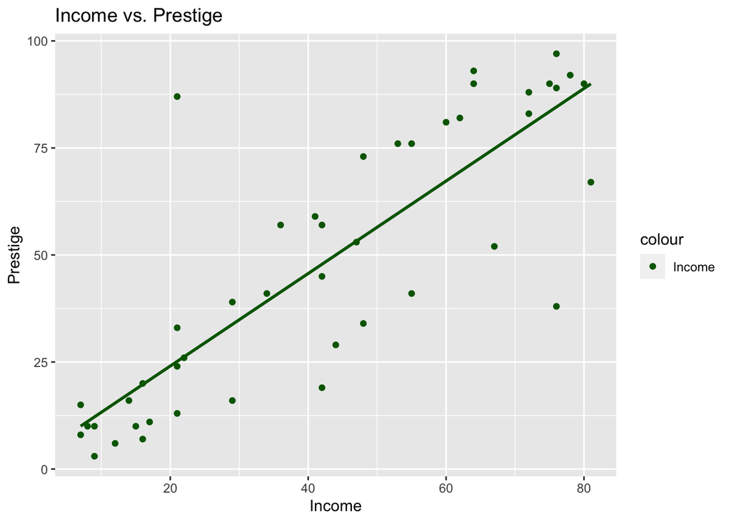

```r
# Create a regression plot for income vs. prestige with custom color
ggplot(data = Duncan, aes(x = income, y = prestige, color = "Income")) +
  geom_point() +
  geom_smooth(method = "lm", se = FALSE, color = income_color) +
  labs(title = "Income vs. Prestige", x = "Income", y = "Prestige") +
  scale_color_manual(values = c("Income" = income_color))
```

I have included two plots: one illustrating the relationship between income and prestige, and the other depicting the relationship between education and prestige.

In the plot representing education and prestige, a linear relationship is evident. Most data points closely align with the linear trend, although some deviate slightly from the line. This minor departure from the straight line can be attributed to the assumption of normality in the data.

In the plot demonstrating income and prestige, a linear relationship is also discernible. However, there is an outlier where prestige is notably high despite lower income. It is advisable to conduct outlier testing for this particular data point. Additionally, it is important to address leverage points, which, if identified as outliers, should be removed from the dataset due to their potential to distort the data. Leverage points that do not meet the criteria for being outliers should be retained, as they exert a substantial influence on the dataset.

```r
mod.type <- lm(Duncan$prestige ~ Duncan$type, data = Duncan)
summary(mod.type)
```

```
##
## Call:
## lm(formula = Duncan$prestige ~ Duncan$type, data = Duncan)
##
## Residuals:
##     Min      1Q  Median      3Q     Max
## -35.444 -11.762   1.238   9.556  44.238
##
## Coefficients:
##                 Estimate Std. Error t value Pr(>|t|)
## (Intercept)       22.762      3.466   6.567 6.08e-08 ***
## Duncan$typeprof   57.683      5.102  11.305 2.54e-14 ***
## Duncan$typewc     13.905      7.353   1.891   0.0655 .
## ---
## Signif. codes:  0 '***' 0.001 '**' 0.01 '*' 0.05 '.' 0.1 ' ' 1
##
## Residual standard error: 15.88 on 42 degrees of freedom
## Multiple R-squared:  0.7574, Adjusted R-squared:  0.7459
## F-statistic: 65.57 on 2 and 42 DF,  p-value: 1.207e-13
```

Based on the analysis, it becomes evident that the observations are primarily influenced by the results for the “bc” and “prof” professions. This discrepancy can be attributed to the imbalance in the dataset concerning the “wc” level.

```r
mod.type <- lm(Duncan$income ~ Duncan$type, data = Duncan)
summary(mod.type)
```

```
##
## Call:
## lm(formula = Duncan$income ~ Duncan$type, data = Duncan)
##
## Residuals:
##     Min      1Q  Median      3Q     Max
## -39.056 -12.056  -2.762  12.238  57.238
##
## Coefficients:
##                 Estimate Std. Error t value Pr(>|t|)
## (Intercept)       23.762      3.834   6.197 2.07e-07 ***
## Duncan$typeprof   36.294      5.644   6.430 9.55e-08 ***
## Duncan$typewc     26.905      8.134   3.308  0.00194 **
## ---
## Signif. codes:  0 '***' 0.001 '**' 0.01 '*' 0.05 '.' 0.1 ' ' 1
##
## Residual standard error: 17.57 on 42 degrees of freedom
## Multiple R-squared:  0.5064, Adjusted R-squared:  0.4829
## F-statistic: 21.54 on 2 and 42 DF,  p-value: 3.642e-07
```

Based on the provided summary, it’s apparent that the observations primarily reflect the outcomes for the “bc” and “prof” categories. This discrepancy may be attributed to the insufficient representation of the “wc” level, which creates an imbalance in the dataset.

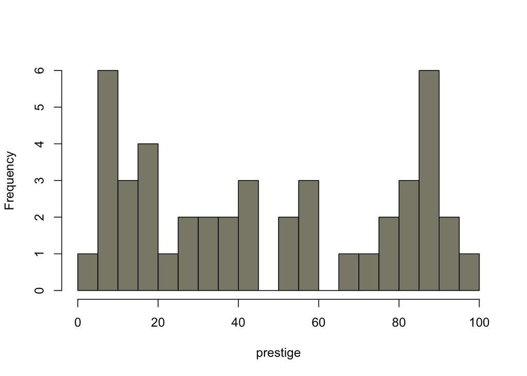

```r
library(e1071)
library("MASS")
hist(Duncan$prestige, breaks=30, main="", xlab="prestige", col ="cornsilk4")
```

```r
skewness(Duncan$prestige)
```

```
## [1] 0.1368965
```

```r
mod.1 <- lm(Duncan$prestige ~., data = Duncan)
summary(mod.1)
```

```
##
## Call:
## lm(formula = Duncan$prestige ~ ., data = Duncan)
##
## Residuals:
##     Min      1Q  Median      3Q     Max
## -14.890  -5.740  -1.754   5.442  28.972
##
## Coefficients:
##              Estimate Std. Error t value Pr(>|t|)
## (Intercept)  -0.18503    3.71377  -0.050  0.96051
## typeprof     16.65751    6.99301   2.382  0.02206 *
## typewc      -14.66113    6.10877  -2.400  0.02114 *
## income        0.59755    0.08936   6.687 5.12e-08 ***
## education     0.34532    0.11361   3.040  0.00416 **
## ---
## Signif. codes:  0 '***' 0.001 '**' 0.01 '*' 0.05 '.' 0.1 ' ' 1
##
## Residual standard error: 9.744 on 40 degrees of freedom
## Multiple R-squared:  0.9131, Adjusted R-squared:  0.9044
## F-statistic:   105 on 4 and 40 DF,  p-value: < 2.2e-16
```

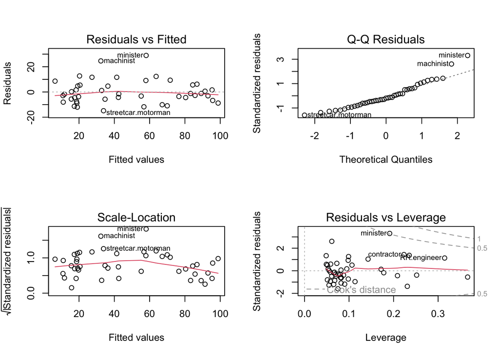

```r
par(mfrow=c(2,2))
plot(mod.1)
```

From the above, summary of the model we can interpret that the intercept value where all the partial co-coefficients are 0 of the variables with corresponds to the response variable. Negative value of -0.18503 indicates negatively co-related and also wc factor value of type var also negatively co-related with value of -14.66113 where as remaining predictor variables such as income and education were positively co-related with 0.59 and 0.34 values respectively. With the less p-value of 2.2e-16 which is less than significance level of 0.05 reject the null hypothesis and conclude that the predictor values are interact with the response variable. The high p-value associated with the intercept indicates that there is no strong evidence to show that the expected prestige at this baseline point is significantly different from zero.

Multiple R-squared which is an important parameter to take into consideration where it indicates the variability, and as the value is 0.9132 we can take as 91.31% which tell us the percent of variables contributing to the model in other words 91.31% of the variance in the response variable (prestige) is explained by the predictor variables that we had fit and the rest has no variability or unexplanined. Adjusted R-squared which build on the R-squared values indicates the good fit of the model.

Residual standard error is 9.744 which means that the actual values of the response variable differ from the predicted values produced by the regression model on the 40 degrees of freedom. The F-statistic tests the overall significance of the model. In this case, the F-statistic has a very low p-value (< 2.2e-16), indicating that the model as a whole is statistically significant.

```r
mod.1 <- lm(Duncan$prestige ~ education * income * type , data = Duncan)
summary(mod.1)
```

```
##
## Call:
## lm(formula = Duncan$prestige ~ education * income * type, data = Duncan)
##
## Residuals:
##      Min       1Q   Median       3Q      Max
## -15.6819  -4.6186  -0.4928   3.1740  22.3316
##
## Coefficients:
##                            Estimate Std. Error t value Pr(>|t|)
## (Intercept)                17.89437   12.36638   1.447   0.1573
## education                  -0.55965    0.50082  -1.117   0.2719
## income                     -0.29036    0.53576  -0.542   0.5915
## typeprof                  -85.48040   58.97604  -1.449   0.1567
## typewc                    -86.67731   58.71481  -1.476   0.1494
## education:income            0.03918    0.01903   2.058   0.0475 *
## education:typeprof          2.03495    0.84976   2.395   0.0225 *
## education:typewc            1.97504    1.07925   1.830   0.0763 .
## income:typeprof             2.49297    1.19344   2.089   0.0445 *
## income:typewc               1.59260    1.00829   1.580   0.1238
## education:income:typeprof  -0.06008    0.02269  -2.648   0.0123 *
## education:income:typewc    -0.05461    0.02395  -2.280   0.0292 *
## ---
## Signif. codes:  0 '***' 0.001 '**' 0.01 '*' 0.05 '.' 0.1 ' ' 1
##
## Residual standard error: 9.015 on 33 degrees of freedom
## Multiple R-squared:  0.9386, Adjusted R-squared:  0.9182
## F-statistic: 45.87 on 11 and 33 DF,  p-value: < 2.2e-16
```

Based on the provided summary, we can make the following observations about the relationships between the predictor variables and the response variable (presitge):

These observations provide insights into how changes in the predictor variables are associated with changes in the response variable, which can be valuable for understanding the relationships in the model.

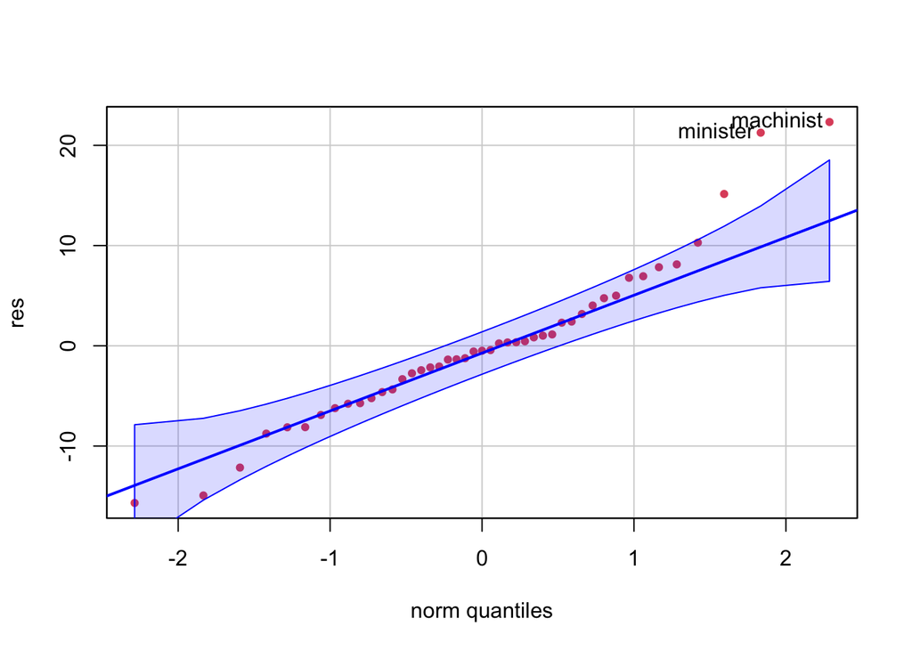

```
## machinist  minister
##        28         6
```

```r
library(e1071)
res <- residuals(mod.1)

car::qqPlot(res, main = NA, pch = 19, col = 2, cex = 0.7)
```

```r
skew <- skewness(res)
cat("skewness of the residuals -> ", skew)
```

```
## skewness of the residuals ->  0.7121299
```

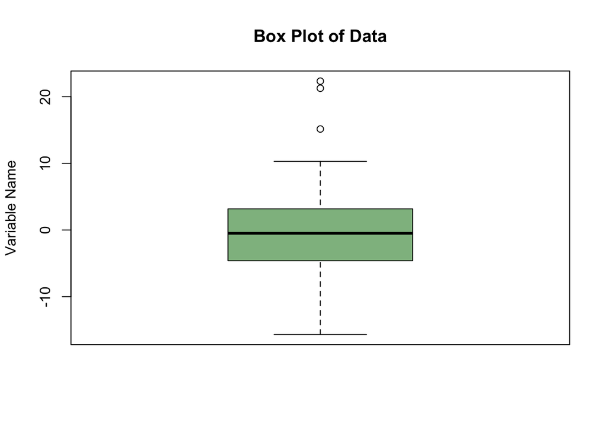

```r
boxplot(res, main = "Box Plot of Data", ylab = "Variable Name", col = "darkseagreen")
```

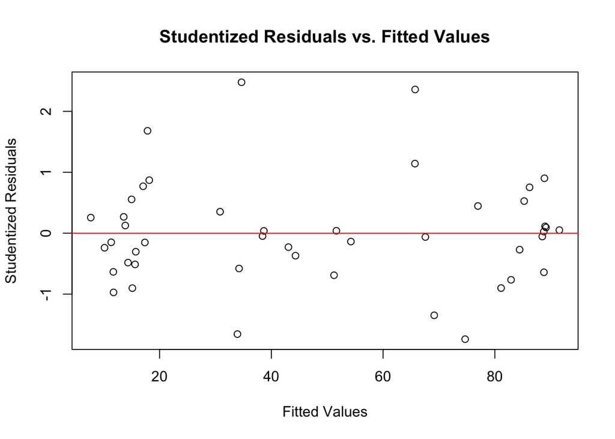

```r
#we need to calcualte the studentised residuals to get the intervals
sigma_residuals <- sigma(mod.1)
studentized_residuals <- res / sigma_residuals


plot(fitted(mod.1), studentized_residuals, xlab = "Fitted Values", ylab = "Studentized Residuals",
     main = "Studentized Residuals vs. Fitted Values")
abline(h = 0, col = "red")
```

From the output we can the residuals follows normality except two data points minister machinist are outliers. As there are outliers in the data and we fitted the model on top of it the model could have been mislead due to the outliers. In this case, we need to decide wether to remove the outliers or not by reaching out to the domain teams. We also need to fit the model by removing the outliers and should interpret the result.s

```r
mod.edu_indcom <- lm(Duncan$prestige ~ Duncan$education + Duncan$income , data = Duncan)
summary(mod.edu_indcom)
```

```
##
## Call:
## lm(formula = Duncan$prestige ~ Duncan$education + Duncan$income,
##     data = Duncan)
##
## Residuals:
##     Min      1Q  Median      3Q     Max
## -29.538  -6.417   0.655   6.605  34.641
##
## Coefficients:
##                  Estimate Std. Error t value Pr(>|t|)
## (Intercept)      -6.06466    4.27194  -1.420    0.163
## Duncan$education  0.54583    0.09825   5.555 1.73e-06 ***
## Duncan$income     0.59873    0.11967   5.003 1.05e-05 ***
## ---
## Signif. codes:  0 '***' 0.001 '**' 0.01 '*' 0.05 '.' 0.1 ' ' 1
##
## Residual standard error: 13.37 on 42 degrees of freedom
## Multiple R-squared:  0.8282, Adjusted R-squared:   0.82
## F-statistic: 101.2 on 2 and 42 DF,  p-value: < 2.2e-16
```

The p-value is less than 2.2e-16, which is extremely small, suggesting the rejection of the null hypothesis. This implies that the coefficients for the predictors are not equal to zero and are statistically significant.

The model exhibits a variability of 82%, which is considered a good fit. This indicates that the model explains a significant portion of the variance in the response variable.

Education and income are positively correlated with the response variable. This means that increases in education and income are associated with increases in the response variable, and these relationships have practical significance.

In summary, the statistical analysis suggests that the model is a good fit, the predictor variables (education and income) are positively correlated with the response variable, and the model’s coefficients are statistically significant, supporting the practical relevance of these predictors in explaining the response variable.

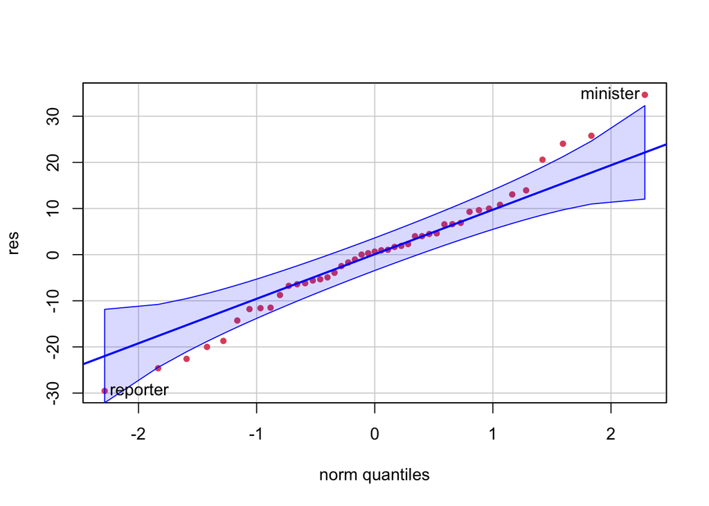

```
## minister reporter
##        6        9
```

```r
res <- residuals(mod.edu_indcom)

car::qqPlot(res, main = NA, pch = 19, col = 2, cex = 0.7)
```

```r
skew <- skewness(res)
cat("skewness of the residuals -> ", skew)
```

```
## skewness of the residuals ->  0.1497963
```

```r
shapiro.test(res)
```

```
##
##  Shapiro-Wilk normality test
##
## data:  res
## W = 0.98254, p-value = 0.7234
```

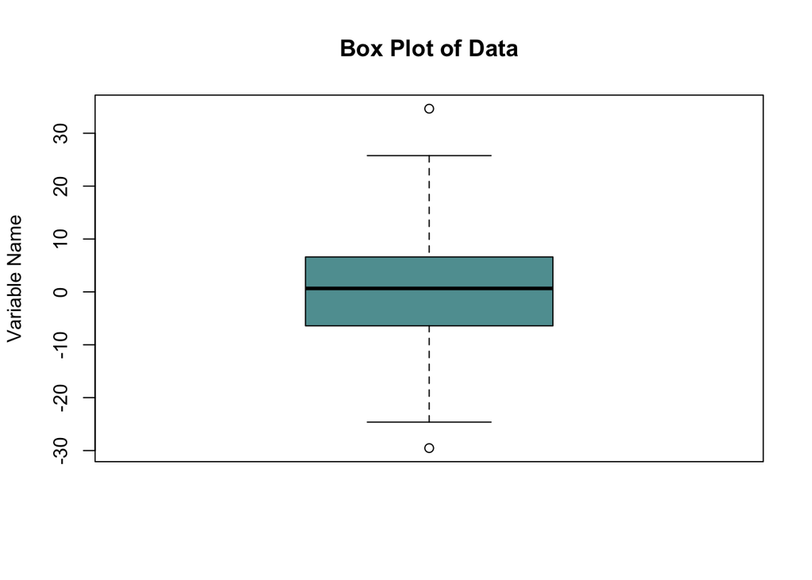

```r
boxplot(res, main = "Box Plot of Data", ylab = "Variable Name", col = "cadetblue")
```

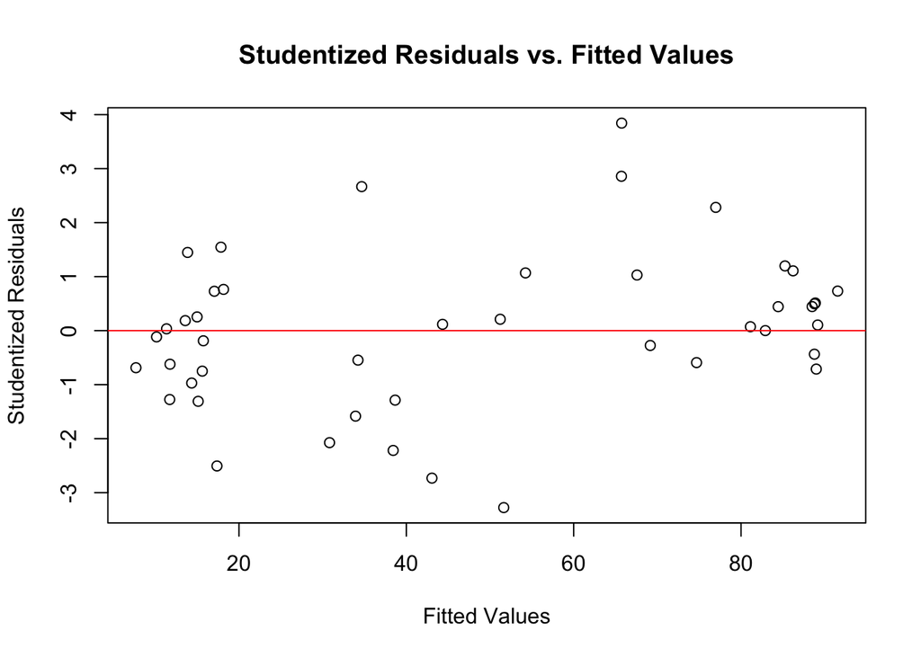

```r
#we need to calcualte the studentised residuals to get the intervals
sigma_residuals <- sigma(mod.1)
studentized_residuals <- res / sigma_residuals


plot(fitted(mod.1), studentized_residuals, xlab = "Fitted Values", ylab = "Studentized Residuals",
     main = "Studentized Residuals vs. Fitted Values")
abline(h = 0, col = "red")
```

However, there is an outlier present in the data. Outliers can have a significant impact on the model and may lead to misleading results. It’s important to assess the nature and potential influence of this outlier on the model.

To address this situation, it is advisable to consider the following:

Investigate the Outlier: Examine the specific data point that is identified as an outlier. Understand its characteristics, potential reasons for its extreme value, and whether it represents a valid data point or an anomaly.

Decide on Outlier Treatment: Depending on the nature of the outlier and its impact on the model, we may need to decide whether to retain, remove, or transform it. This decision should be made in consideration of the research or business context.

Assess Model Sensitivity: Consider re-running the model with and without the outlier to assess its influence on the model’s coefficients, performance, and predictions.

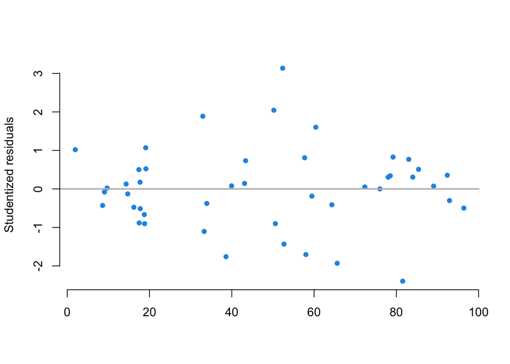

```r
plot(jitter(mod.edu_indcom$fitted.values), rstudent(mod.edu_indcom), pch=19,
     col=ifelse(Duncan$prestige == 0, 3, 4),cex=0.8, xlab="",
     ylab="Studentized residuals", axes=F)
abline(h=0,col="grey", lwd=2)
axis(1);axis(2)
```

The chart suggests that the model appears to be reasonable. This implies that the model fits the data well and is generally in accordance with the assumptions of linear regression.

However, there is a concern regarding the magnitude of the residuals. Typically, it is expected that most of the Studentized residuals should fall within the range of -3 to 3. The presence of some residuals outside this range may indicate that there are data points where the model’s predictions are significantly different from the actual values, which can be a concern.

The mention of a “partial regression plot” is important. In this context, it indicates that we are exploring the relationship between individual predictors and the response variable while holding other predictor variables constant. This can provide insights into the unique contribution of each predictor to the response variable.

To address the concern about residuals outside the expected range, we may want to further investigate the data points associated with these extreme residuals and consider whether there are influential data points or outliers that require attention. Additionally, we can use the partial regression plot to assess how each predictor influences the response variable in isolation from the other predictors, which can help we better understand the relationships within the model.

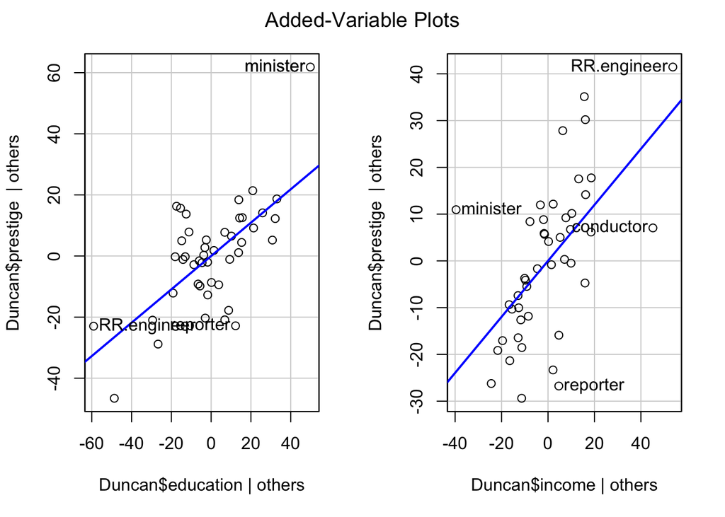

```r
avPlots(mod.edu_indcom)
```

The partial residual plots for education and income are used to examine the relationship between each of these variables and the residuals from a full linear regression model that includes both education and income as predictors. These plots provide insights into the influence of each predictor variable on the model’s residuals while considering the other predictor variables.

Here’s what we can learn from these partial residual plots:

Education Partial Residual Plot: This plot will show how the residuals vary with changes in the education variable while keeping income constant. If the plot exhibits a clear pattern (e.g., a linear trend), it suggests that education has a significant influence on the response variable, and the relationship between education and the residuals is not adequately explained by the model.

Income Partial Residual Plot: Similarly, the income partial residual plot will demonstrate how the residuals change with varying income levels, while holding education constant. If this plot also shows a discernible pattern, it indicates that income has an influence on the response variable that is not accounted for by the model.

By examining these partial residual plots, we can identify potential nonlinear relationships between the individual predictor variables and the residuals, which may lead to a better understanding of the model’s limitations or suggest the need for additional model adjustments or transformations to capture the underlying relationships more accurately.

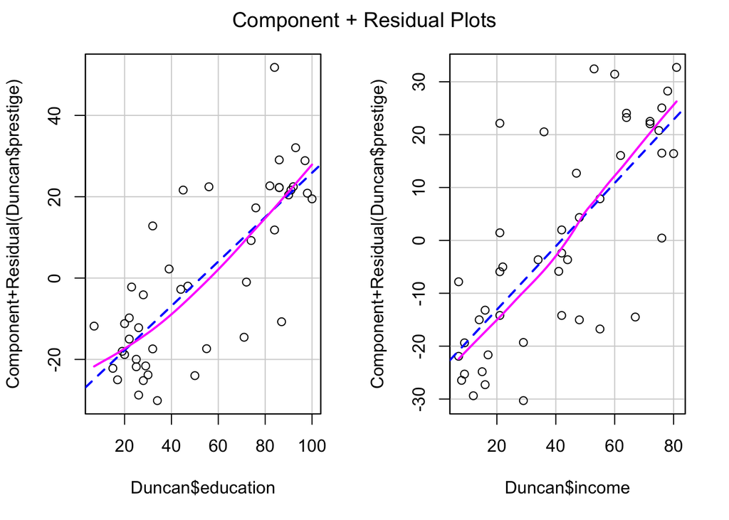

```r
crPlots(mod.edu_indcom)
```

In a linear regression model, the effect size can be summarized by the R-squared values. R-squared indicates how well the model fits the data, with a higher value indicating a better fit. It quantifies the proportion of variability in the response variable that is explained by the predictor variables. Its value ranges from 0 to 1.

For instance, in our model, we mentioned an R-squared value of 0.8282, which translates to 82%. This means that approximately 82% of the variability in the response variable is accounted for by the predictors in the model. However, it’s important to note that R-squared values are not the sole contributors to the effect size. Other factors, such as the magnitude and significance of the individual predictor coefficients, should also be considered when assessing the overall effect size and the practical significance of the predictors in explaining the response variable.